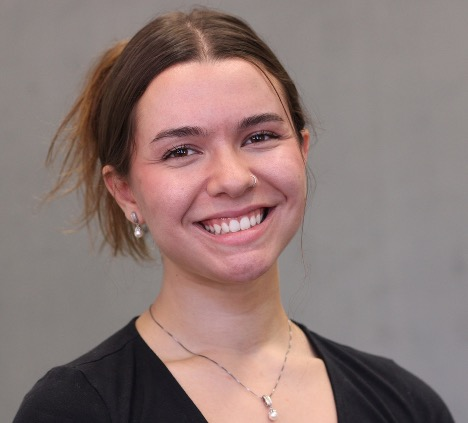

# Amirah Casey

## Bio

Amirah recently graduated from Western Washington University with a BS in Marine and Coastal Science with a minor in Spanish. While at WWU, she took part in research on the effects of PCBs and PBDEs on zebrafish and surf smelt. During her four years as an undergraduate, she was a marine science education intern at foundry10, the first undergraduate to teach a lab section of organismal biology, and a peer mentor for the Marine and Coastal Science. As of 2023, Amirah began attending the University of Washington School of Aquatic and Fishery Science. She is a member of the Applied Ecology Lab and is advised by Dr. Mark Scheuerell. In addition to her studies in SAFS, Amirah is a member of the Future Rivers program and is on the board of Students Explore Aquatic Science (SEAS). Pertaining to graduate studies, she is interested in mitigating the effects of contaminant and thermal stress on salmon in the Pacific Northwest through her collaboration with the NOAA Ecotoxicology program.

## Education

**Western Washington University** | Bellingham, WA

- B.S. in Marine and Coastal Science, Spanish minor | September 2019 - June 2023

**University of Washington** | Seattle, WA

- School of Aquatic and Fishery Science| September 2023 - Future date

## Research

I am broadly interested in Urban Ecology and Climate Resilience, and through graduate school I hope to gain experience doing research at the intersection of science and policy while improving my quantitative and computational skills. As such, my project focuses on how urbanization and climate change are impacting Puget Sound. Specifically, I hope to understand how higher stream temperatures interact with contaminant 6PPD-quinone to impact Coho salmon physiology. I will do this through empirical studies in the lab, as well as updating a pre-existing model that will account for thermal stress when calculating predicted Coho mortality across Puget Sound.

I have also created an educational StoryMap that explores the impacts of stormwater runoff, specifically 6PPD-q, in the Pacific Northwest.

[Visit my StoryMap](https://arcg.is/0meSj9)